# Community network plots

Gibran Hemani

```r
library(knitr)
opts_chunk$set(cache=FALSE, echo=TRUE, message=FALSE, warning=FALSE)
set.seed(12345)
```

Plot:

- community 2 = largest
- community 9 = cohesin
- community 22 = nfkb
- community 76 = ezh2

```r
library(dplyr)
library(googleVis)
library(networkD3)
library(rbokeh)
library(htmlwidgets)
library(igraph)
library(purrr)
library(ggbio)
library(GenomicRanges)
# Also need to install phantomjs
# brew tap homebrew/cask
# brew cask install phantomjs


make_sankey <- function(userset, out, snpanno, options = list(height=600, width=700), method=c("googlevis", "networkd3")[1])
{
    temp <- subset(out, userSet == userset) %>% mutate(snp=gsub(":SNP", "", snp))
    snpanno <- snpanno %>% ungroup %>% mutate(snp=gsub(":SNP", "", snp))
    out <- mutate(out, snp=gsub(":SNP", "", snp))
    bigdat <- list(
        filter(snpanno, snp %in% temp$snp) %>%
            ungroup() %>%
            select(start=antibody, end=snp, weight=n) %>%
            mutate(section=1),
        filter(temp, !duplicated(paste(snp, cpg))) %>%
            ungroup() %>%
            mutate(weight=as.numeric(cis) * -1 + 2, section=2) %>%
            select(start=snp, end=cpg, weight=weight, section=section),
        temp %>% ungroup %>%
            mutate(section=3) %>%
            select(start=cpg, end=antibody, weight=pValueLog, section=section)
    ) %>% bind_rows()
    # If any snp has no annotation, give it one
    snplist <- unique(temp$snp)
    missnp <- snplist[!snplist %in% subset(bigdat, section == 1)$end]
    if(length(missnp) > 0)
    {
        message(missnp)
        bigdat <- bind_rows(bigdat, data_frame(start="No annotation", end=missnp, weight=1, section=1)) %>% arrange(section)
    }
    cpglist <- unique(temp$cpg)
    miscpg <- cpglist[!cpglist %in% subset(bigdat, section == 3)$start]
    if(length(miscpg) > 0)
    {
        message(miscpg)
        bigdat <- bind_rows(bigdat, data_frame(start=miscpg, end="No annotation", weight=1, section=3)) %>% arrange(section)
    }

    bigdat$end[bigdat$section==3] <- paste0(bigdat$end[bigdat$section==3], " ")
    if(method == "googlevis")
    {
        a <- gvisSankey(subset(bigdat), from="start", to="end", weight="", options=options)
        a$html$footer <- "</body>\n</html>"
        a$html$caption <- ""
        return(a)
    } else if(method == "networkd3")
    {
        nom <- tibble(name=unique(c(bigdat$start, bigdat$end)))
        nom$index <- 1:nrow(nom)-1

        bigdat <- merge(bigdat, nom, by.x="start", by.y="name")
        names(bigdat)[names(bigdat) == "index"] <- "source"
        bigdat <- merge(bigdat, nom, by.x="end", by.y="name")
        names(bigdat)[names(bigdat) == "index"] <- "target"
        bigdat$value <- 1

        o <- sankeyNetwork(Links=bigdat, Nodes=nom, Source="source", Target="target", Value="value", NodeID="name", fontSize = 18, fontFamily="Arial", height=options$height, width=options$width)
        return(o)
    }
}
```

Load the results from `plot_setup.rmd` and modify the `sheffield_dnase` annotations to be only present for DNAse hypersensitivity in blood

```r
load("../results/plotting_community_enrichments.rdata")

snpo2$antibody[is.na(snpo2$antibody)] <- snpo2$description[is.na(snpo2$antibody)]
ind <- snpo2$collection == "sheffield_dnase"
ind2 <- grepl("Hematop", snpo2$antibody) | grepl("sheffield_dnase", snpo2$antibody)
snpo2$antibody[ind] <- NA
snpo2$antibody[ind2] <- "Blood Dnase HS"
snpo2 <- subset(snpo2, !is.na(antibody))
snpanno <- group_by(snpo2, snp, antibody) %>%
    summarise(n=n()) %>%
    arrange(desc(n)) %>%
    filter(between(row_number(), 1, pmin(10, n())))
```

Save plots in `networkD3` format

```r
a <- make_sankey(2, out, snpanno, list(height=1600, width=1000), "networkd3")
widget2png(a, "../images/sankey2.png")

a <- make_sankey(22, out, snpanno, list(height=600, width=1000), "networkd3")
widget2png(a, "../images/sankey22.png")

a <- make_sankey(76, out, snpanno, list(height=300, width=1000), "networkd3")
widget2png(a, "../images/sankey76.png")

a <- make_sankey(9, out, snpanno, list(height=700, width=1000), "networkd3")
widget2png(a, "../images/sankey9.png")
```

Save plots in `googleVis` format. This has to be done manually - `plot(a)` will open in a webpage. Print the webpage to pdf and then crop manually. This is how to create the files `../images/gvsankey2.pdf` etc.

```r
a <- make_sankey(2, out, snpanno, list(height=1600, width=1000), "googlevis")
plot(a)

a <- make_sankey(22, out, snpanno, list(height=600, width=1000), "googlevis")
plot(a)

a <- make_sankey(76, out, snpanno, list(height=300, width=1000), "googlevis")
plot(a)

a <- make_sankey(9, out, snpanno, list(height=700, width=1000), "googlevis")
plot(a)
```

## Network plots

Setup data

```r
# load("../results/gwas_clusters_nochr6.rdata")
# info <- read.csv("../../data/gwas/00info.csv")
# info <- data.frame(fn=gsub(".txt.gz", "", info$newfile), id=info$id)

# labels <- subset(res, !duplicated(i), select=c(i, fn))
# labels$fn <- gsub("../../data/gwas/", "", labels$fn)
# labels$fn <- gsub(".txt.gz", "", labels$fn)
# dat <- merge(dat, labels, by.x="id", by.y="i")
# sign<-0.05/nrow(dat)
# g<-grep("metabolites__",dat$fn)
# gwa<-dat[-g,]
# gwa<-gwa[which(gwa$binom4<sign),]
# gwa.clust<-unique(gwa$clust)

rm(list=ls())
load("../results/graph.rdata")

memcount <- group_by(mem, cluster) %>%
    summarise(n=n()) %>%
    arrange(desc(n))

dat <- group_by(dat, creg) %>%
    mutate(snp1=snp[1])

extract_subset <- function(gr, dat, cpg_list)
{
    keep <- subset(dat, creg %in% cpg_list | tcpg %in% cpg_list)
    keep1 <- subset(keep, select=c(creg, tcpg))
    keep1$type <- "CpG"
    keep2 <- data_frame(creg=keep$snp1, tcpg=keep$creg, type="cis")
    keep3 <- data_frame(creg=keep$snp1, tcpg=keep$tcpg, type="trans")
    keep <- bind_rows(keep1, keep2, keep3)
    keep$lab <- paste(keep$creg, keep$tcpg)
    dup <- keep$lab[duplicated(keep$lab)]
    subset(keep, lab %in% dup)
    keep <- subset(keep, !duplicated(lab))
    # keep <- subset(keep, type == "CpG")
    c <- graph_from_data_frame(keep)
    V(c)$what <- "CpG"
    V(c)[grepl("chr", V(c)$name)]$what <- "SNP"
    V(c)$color <- ifelse(grepl("SNP", names(V(c))), 2, 3)
    return(list(gr=c, dat=keep))
}

plot_community <- function(cluster)
{
    temp <- extract_subset(gr, dat, mem$cpg[mem$cluster == cluster])
    plot(temp$gr,
        layout=layout.fruchterman.reingold,
        # vertex.color=as.numeric(as.factor(V(temp$gr)$what)),
        vertex.size=(as.numeric(as.factor(V(temp$gr)$what))-5)^2,
        vertex.label=NA,
        edge.arrow.size=0,
        edge.color=as.numeric(as.factor(E(temp$gr)$type))
    )
}
```

Plot community that contains longest distance

```r
(temp <- farthest.nodes(gr))
```

```
## $vertices
## + 2/5109 vertices, named, from 49a2070:
## [1] cg07186576 cg26380291
##
## $distance
## [1] 2
```

```r
temp <- all_simple_paths(gr, temp$vertices[1], temp$vertices[2])
temp <- extract_subset(gr, dat, names(temp[[1]]))
pdf(file="../images/plot_longest1.pdf")
plot(temp$gr,
    layout=layout.fruchterman.reingold,
    # vertex.color=as.numeric(as.factor(V(temp$gr)$what)),
    vertex.size=(as.numeric(as.factor(V(temp$gr)$what))-5)^2,
    vertex.label=NA,
    edge.arrow.size=0,
    edge.color=as.numeric(as.factor(E(temp$gr)$type))
)
dev.off()
```

Plot community 6

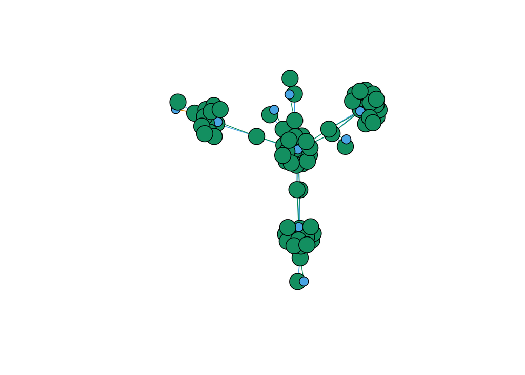

```r
plot_community(6)
```

Plot all communites with >= 5 CpGs

```r
todo <- subset(memcount, n >= 5)$cluster
```

This will be 131 communities

```r
dir.create("../images/community_plots/", recursive=TRUE)
for(i in todo)
{
    message(i)
    temp <- extract_subset(gr, dat, mem$cpg[mem$cluster == i])
    pdf(paste0("../images/community_plots/cluster", i, ".pdf"))
    plot(temp$gr,
        layout=layout.fruchterman.reingold,
        # vertex.color=as.numeric(as.factor(V(temp$gr)$what)),
        vertex.size=(as.numeric(as.factor(V(temp$gr)$what))-5)^2,
        vertex.label=NA,
        edge.arrow.size=0,
        edge.color=as.numeric(as.factor(E(temp$gr)$type))
    )
    dev.off()
}
```

What do these look like on circos plots?

Define chromosome ranges:

```r
hg19chr <- GRanges(seqnames=c("chr1", "chr2", "chr3", "chr4", "chr5", "chr6", "chr7", "chr8", "chr9", "chr10", "chr11", "chr12", "chr13", "chr14", "chr15", "chr16", "chr17", "chr18", "chr20", "chr19", "chr21", "chr22", "chr23"),
    IRanges(rep(1,23),
        c(249250621,243199373,198022430,191154276,180915260,171115067,155270560,146364022,141213431,135534747,135006516,133851895,115169878,107349540,102531392,90354753,81195210,78077248,63025520,59128983,48129895, 51304566, 159138663)
    )
)
```

This function wrangles the data for a specific community

```r
extract_subset_granges <- function(gr, dat, cpg_list, hg19chr)
{
    keep <- subset(dat, creg %in% cpg_list | tcpg %in% cpg_list)
    keep <- tidyr::separate(keep, snp, c("snpchr", "snppos", "snptype"), sep=":", remove=FALSE)
    g1 <- GRanges(seqnames=keep$creg_chr, IRanges(keep$creg_pos, keep$creg_pos))
    g2 <- GRanges(seqnames=keep$tcpg_chr, IRanges(keep$tcpg_pos, keep$tcpg_pos))
    g1 <- c(hg19chr, g1)
    g2 <- c(hg19chr, g2)
    g1$topos <- g2
    g1 <- g1[-c(1:length(hg19chr))]

    temp <- subset(keep, !duplicated(snp))
    g3 <- GRanges(seqnames=temp$snpchr, IRanges(as.numeric(temp$snppos), as.numeric(temp$snppos)))
    g3$what <- "snp"
    temp <- subset(keep, !duplicated(creg))
    g4 <- GRanges(seqnames=temp$creg_chr, IRanges(as.numeric(temp$creg_pos), as.numeric(temp$creg_pos)))
    g4$what <- "creg"
    temp <- subset(keep, !duplicated(tcpg))
    g5 <- GRanges(seqnames=temp$tcpg_chr, IRanges(as.numeric(temp$tcpg_pos), as.numeric(temp$tcpg_pos)))
    g5$what <- "tcpg"

    g3$y <- 0
    g4$y <- 0
    g5$y <- 0
    pos <- c(g3,g4,g5)
    h <- hg19chr
    h$what <- NA
    h$y <- NA
    pos <- c(h, pos)
    return(list(links=g1, pos=pos))
}

plot_circle <- function(temp, hg19chr)
{
    ggplot() +
        layout_circle(temp$pos[1:23], geom = "ideo", fill = "black", radius = 8.4, trackWidth = 0.2) +
        layout_circle(temp$links, geom = "link", linked.to = "topos", radius=6) +
        layout_circle(temp$pos[-c(1:23)], geom = "point", aes(x=y, colour=what), size=6, radius=6) +
        scale_colour_manual(values=c("#9ecae1", "#a1d99b", "#31a354")) +
        theme(legend.position="none")

}
```

Do all communities with 5 or more CpGs

```r
todo <- subset(memcount, n >= 5)$cluster
for(i in todo)
{
    message(i)
    temp <- extract_subset_granges(gr, dat, mem$cpg[mem$cluster == i], hg19chr)
    pdf(paste0("../images/community_plots/cluster_circle", i, ".pdf"))
    p <- plot_circle(temp, hg19chr)
    print(p)
    dev.off()
}
```

## Full graph plots

Get hub and authority scores for each CpG

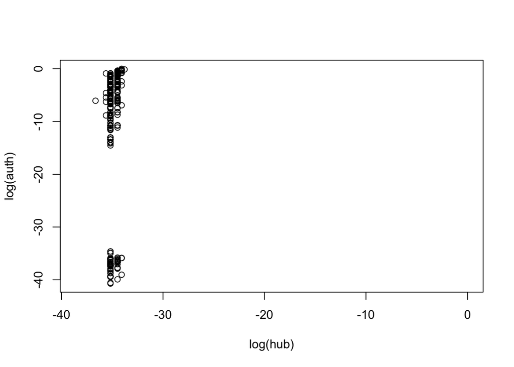

```r
hub <- hub.score(gr)$vector
auth <- authority.score(gr)$vector

plot(log(hub), log(auth))
```

Try plotting all

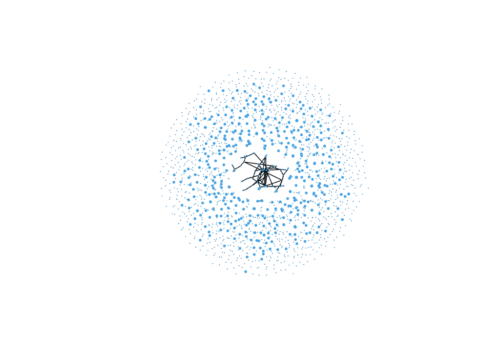

```r
plot(gr, layout=layout.drl, vertex.color=abs(as.numeric(hub > 1)-2), vertex.frame.color=abs(as.numeric(hub > 1)-2), vertex.size = hub, vertex.label = NA, edge.arrow.size = 0, edge.width=1, edge.color="black")
```

Looks busy.. Try extracting only communities with 10 or more CpGs

```r
com <- dplyr::as_data_frame(mem)
names(com) <- c("cpg", "mem")
a <- group_by(com, mem) %>%
    summarise(n=n()) %>%
    filter(n >= 10)

comkeep <- subset(com, mem %in% a$mem)
remcpg <- com$cpg[!com$cpg %in% comkeep$cpg]
grc <- delete_vertices(gr, remcpg)

hub <- (hub.score(grc)$vector + 2)^2 - 1
ind <- match(comkeep$cpg, V(grc)$name)
all(V(grc)$name == comkeep$cpg)
```

```
## [1] TRUE
```

```r
V(grc)$community <- comkeep$mem
V(grc)$community2 <- V(grc)$community
V(grc)$community2[duplicated(V(grc)$community2)] <- NA
pdf(file="../images/community_plot_10plus.pdf")
plot(grc, layout=layout.fruchterman.reingold, vertex.color=V(grc)$community, vertex.frame.color=V(grc)$community, vertex.size = 2, vertex.label = V(grc)$community2, edge.arrow.size = 0)
dev.off()
```

Try with only 15 or more

```r
com <- dplyr::as_data_frame(mem)
names(com) <- c("cpg", "mem")
a <- group_by(com, mem) %>%
    summarise(n=n()) %>%
    filter(n >= 15)

comkeep <- subset(com, mem %in% a$mem)
remcpg <- com$cpg[!com$cpg %in% comkeep$cpg]
grc <- delete_vertices(gr, remcpg)

hub <- (hub.score(grc)$vector + 2)^2 - 1
ind <- match(comkeep$cpg, V(grc)$name)
all(V(grc)$name == comkeep$cpg)
```

```
## [1] TRUE
```

```r
V(grc)$community <- comkeep$mem
V(grc)$community2 <- V(grc)$community
V(grc)$community2[duplicated(V(grc)$community2)] <- NA
pdf(file="../images/community_plot_15plus.pdf")
plot(grc, layout=layout.fruchterman.reingold, vertex.color=V(grc)$community, vertex.frame.color=V(grc)$community, vertex.size = 2, vertex.label = V(grc)$community2, edge.arrow.size = 0)
dev.off()
```

20 or more…

```r
com <- dplyr::as_data_frame(mem)
names(com) <- c("cpg", "mem")
a <- group_by(com, mem) %>%
    summarise(n=n()) %>%
    filter(n >= 20)

comkeep <- subset(com, mem %in% a$mem)
remcpg <- com$cpg[!com$cpg %in% comkeep$cpg]
grc <- delete_vertices(gr, remcpg)

hub <- (hub.score(grc)$vector + 2)^2 - 1
ind <- match(comkeep$cpg, V(grc)$name)
all(V(grc)$name == comkeep$cpg)
```

```
## [1] TRUE
```

```r
V(grc)$community <- comkeep$mem
V(grc)$community2 <- V(grc)$community
V(grc)$community2[duplicated(V(grc)$community2)] <- NA
pdf(file="../images/community_plot_20plus.pdf")
plot(grc, layout=layout.fruchterman.reingold, vertex.color=V(grc)$community, vertex.frame.color=V(grc)$community, vertex.size = (as.numeric(!is.na(V(grc)$community2))) * 5, vertex.label = V(grc)$community2, edge.arrow.size = 0, vertex.label.family="sans", vertex.label.color="black", vertex.label.cex=0.5)
dev.off()
```